# Comparativa de modelos de clasificacion

# Creando las datos para entrenamiento y testeo

```r
set.seed(100)  # Para reproducir los mismos resultados
IndicesEntrenamiento <- createDataPartition(y = iris$Species,
                                            p = 0.75,
                                            list = FALSE)
datosTrain <- iris[IndicesEntrenamiento,]
datosTest <- iris[-IndicesEntrenamiento,]
```

Revisamos el número de filas de cada conjunto de datos.

```r
nrow(datosTrain)
```

```
[1] 114
```

```r
nrow(datosTest)
```

```
[1] 36
```

Revisamos la distribución de clases en el conjunto de datos para el entrenamiento y test con la función table.

```r
table(datosTrain$Species)
```

```
    setosa versicolor  virginica
        38         38         38
```

```r
table(datosTest$Species)
```

```
    setosa versicolor  virginica
        12         12         12
```

# Comparativa de métodos de clasificación

## El comando train (función del paquete caret)

Se puede usar este comando único para aplicar un gran número de métodos de clasificación determinando (en caso necesario) los valores óptimos de sus parámetros mediante validación cruzada u otros métodos de remuestreo. Para usar train en general es necesario:

- Elegir el método de clasificación que queremos usar. El catálogo de todos los métodos disponibles se puede consultar en este enlace. Una información técnica detallada de cada método se puede obtener con el comando getModelInfo.
- Si el método de clasificación requiere determinar parámetros, es necesario fijar cuáles y en qué rango de valores.
- También hay que definir el método de remuestreo que se va a utilizar para determinar estos parámetros.

## Decision Trees

También se podría hacer usando:

modeloTrees <- rpart(formula = Species ~ ., data = datosTrain)

Después mostraremos las caracteristicas del modelo:

```r
modeloTrees<-train(Species ~ . ,data =datosTrain, method="rpart")
modeloTrees
```

```
CART

114 samples
  4 predictor
  3 classes: 'setosa', 'versicolor', 'virginica'

No pre-processing
Resampling: Bootstrapped (25 reps)
Summary of sample sizes: 114, 114, 114, 114, 114, 114, ...
Resampling results across tuning parameters:

  cp         Accuracy   Kappa
  0.0000000  0.9488568  0.9222865
  0.4342105  0.7546142  0.6465625
  0.5000000  0.5301283  0.3260989

Accuracy was used to select the optimal model using the largest value.
The final value used for the model was cp = 0.
```

Dibujar el arbol:

```r
# El modelo final del arbol se guarda en este atributo
modeloTrees$finalModel
```

```
n= 114

node), split, n, loss, yval, (yprob)
      * denotes terminal node

1) root 114 76 setosa (0.3333333 0.3333333 0.3333333)
  2) Petal.Length< 2.45 38  0 setosa (1.0000000 0.0000000 0.0000000) *
  3) Petal.Length>=2.45 76 38 versicolor (0.0000000 0.5000000 0.5000000)
    6) Petal.Length< 4.75 33  0 versicolor (0.0000000 1.0000000 0.0000000) *
    7) Petal.Length>=4.75 43  5 virginica (0.0000000 0.1162791 0.8837209) *
```

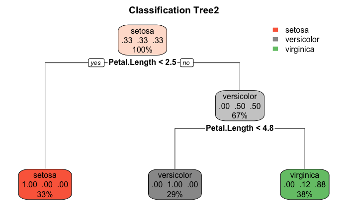

```r
rpart.plot(modeloTrees$finalModel, main="Classification Tree2")
```

## Predecir los valores para el conjunto de test

```r
# Predict
prediccionTrees=predict(modeloTrees, datosTest)
```

Indicadores de accuracy, precision, sensitivity y especificidad:

```r
# Genera una matriz de confusion
confusionMatrix(prediccionTrees, datosTest$Species)$table
```

```
            Reference
Prediction   setosa versicolor virginica
  setosa         12          0         0
  versicolor      0         11         1
  virginica       0          1        11
```

```r
# Mostrar la precision
confusionMatrix(prediccionTrees, datosTest$Species)$overall
```

```
      Accuracy          Kappa  AccuracyLower  AccuracyUpper   AccuracyNull AccuracyPValue
  9.444444e-01   9.166667e-01   8.133633e-01   9.931997e-01   3.333333e-01   1.727577e-14
 McnemarPValue
           NaN
```

```r
confusionMatrix(prediccionTrees, datosTest$Species)$byClass
```

```
                  Sensitivity Specificity Pos Pred Value Neg Pred Value Precision    Recall
Class: setosa       1.0000000   1.0000000      1.0000000      1.0000000 1.0000000 1.0000000
Class: versicolor   0.9166667   0.9583333      0.9166667      0.9583333 0.9166667 0.9166667
Class: virginica    0.9166667   0.9583333      0.9166667      0.9583333 0.9166667 0.9166667
                         F1 Prevalence Detection Rate Detection Prevalence Balanced Accuracy
Class: setosa     1.0000000  0.3333333      0.3333333            0.3333333            1.0000
Class: versicolor 0.9166667  0.3333333      0.3055556            0.3333333            0.9375
Class: virginica  0.9166667  0.3333333      0.3055556            0.3333333            0.9375
```

## Random Forest

```r
modeloRF<-train(Species ~ . ,data =datosTrain, method="cforest")
```

```r
modeloRF$modelInfo
```

```
$label
[1] "Conditional Inference Random Forest"

$library
[1] "party"

$loop
NULL

$type
[1] "Classification" "Regression"

$parameters
```

| parameter | class | label |
| --- | --- | --- |
| mtry | numeric | #Randomly Selected Predictors |

[output not shown]

[output cut: 39 more lines]

[output not shown]

```r
modeloRF$finalModel
```

```
     Random Forest using Conditional Inference Trees

Number of trees:  500

Response:  .outcome
Inputs:  Sepal.Length, Sepal.Width, Petal.Length, Petal.Width
Number of observations:  114
```

Las variables más significativas en el modelo son:

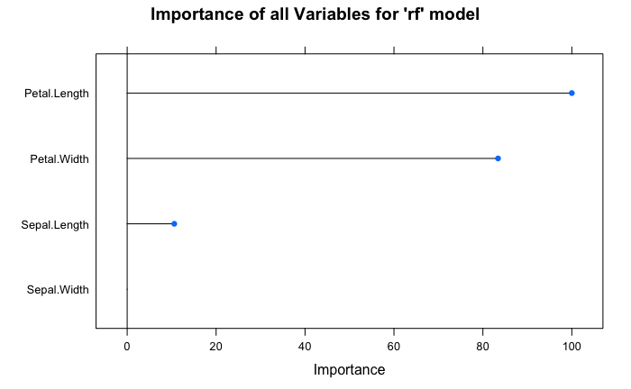

```r
modeloRF.varImp = varImp(modeloRF)
plot(modeloRF.varImp, main = "Importance of all Variables for 'rf' model")
```

```r
# Predict
prediccionRF<-predict(modeloRF, datosTest)
```

Indicadores de accuracy, precision, sensitivity y especificidad:

```r
# Genera una matriz de confusion
confusionMatrix(prediccionRF, datosTest$Species)$table
```

```
            Reference
Prediction   setosa versicolor virginica
  setosa         12          0         0
  versicolor      0         11         1
  virginica       0          1        11
```

```r
# Mostrar la precision
confusionMatrix(prediccionRF, datosTest$Species)$overall
```

```
      Accuracy          Kappa  AccuracyLower  AccuracyUpper   AccuracyNull AccuracyPValue
  9.444444e-01   9.166667e-01   8.133633e-01   9.931997e-01   3.333333e-01   1.727577e-14
 McnemarPValue
           NaN
```

```r
confusionMatrix(prediccionRF, datosTest$Species)$byClass
```

```
                  Sensitivity Specificity Pos Pred Value Neg Pred Value Precision    Recall
Class: setosa       1.0000000   1.0000000      1.0000000      1.0000000 1.0000000 1.0000000
Class: versicolor   0.9166667   0.9583333      0.9166667      0.9583333 0.9166667 0.9166667
Class: virginica    0.9166667   0.9583333      0.9166667      0.9583333 0.9166667 0.9166667
                         F1 Prevalence Detection Rate Detection Prevalence Balanced Accuracy
Class: setosa     1.0000000  0.3333333      0.3333333            0.3333333            1.0000
Class: versicolor 0.9166667  0.3333333      0.3055556            0.3333333            0.9375
Class: virginica  0.9166667  0.3333333      0.3055556            0.3333333            0.9375
```

## k-Nearest Neighbours

```r
modeloKNN<-train(Species ~ . ,data =datosTrain, method="knn")
modeloKNN
```

```
k-Nearest Neighbors

114 samples
  4 predictor
  3 classes: 'setosa', 'versicolor', 'virginica'

No pre-processing
Resampling: Bootstrapped (25 reps)
Summary of sample sizes: 114, 114, 114, 114, 114, 114, ...
Resampling results across tuning parameters:

  k  Accuracy   Kappa
  5  0.9487924  0.9225874
  7  0.9521724  0.9275674
  9  0.9577754  0.9360280

Accuracy was used to select the optimal model using the largest value.
The final value used for the model was k = 9.
```

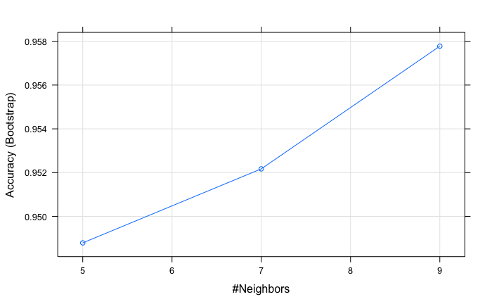

```r
plot(modeloKNN)
```

```r
# Predict
prediccionKNN=predict(modeloKNN, datosTest)
```

Métricas para evaluar el modelo:

```r
# Genera una matriz de confusion
confusionMatrix(prediccionKNN, datosTest$Species)$table
```

```
            Reference
Prediction   setosa versicolor virginica
  setosa         12          0         0
  versicolor      0         11         1
  virginica       0          1        11
```

```r
# Mostrar la precision
confusionMatrix(prediccionKNN, datosTest$Species)$overall
```

```
      Accuracy          Kappa  AccuracyLower  AccuracyUpper   AccuracyNull AccuracyPValue
  9.444444e-01   9.166667e-01   8.133633e-01   9.931997e-01   3.333333e-01   1.727577e-14
 McnemarPValue
           NaN
```

```r
confusionMatrix(prediccionKNN, datosTest$Species)$byClass
```

```
                  Sensitivity Specificity Pos Pred Value Neg Pred Value Precision    Recall
Class: setosa       1.0000000   1.0000000      1.0000000      1.0000000 1.0000000 1.0000000
Class: versicolor   0.9166667   0.9583333      0.9166667      0.9583333 0.9166667 0.9166667
Class: virginica    0.9166667   0.9583333      0.9166667      0.9583333 0.9166667 0.9166667
                         F1 Prevalence Detection Rate Detection Prevalence Balanced Accuracy
Class: setosa     1.0000000  0.3333333      0.3333333            0.3333333            1.0000
Class: versicolor 0.9166667  0.3333333      0.3055556            0.3333333            0.9375
Class: virginica  0.9166667  0.3333333      0.3055556            0.3333333            0.9375
```

##Support Vector Machine (SVM)

```r
modeloSVM=train(Species~., data=datosTest,
                method="svmLinear")

modeloSVM
```

```
Support Vector Machines with Linear Kernel

36 samples
 4 predictor
 3 classes: 'setosa', 'versicolor', 'virginica'

No pre-processing
Resampling: Bootstrapped (25 reps)
Summary of sample sizes: 36, 36, 36, 36, 36, 36, ...
Resampling results:

  Accuracy  Kappa
  0.956026  0.9307712

Tuning parameter 'C' was held constant at a value of 1
```

```r
# Predict
prediccionSVN=predict(modeloSVM, datosTest)
```

Métricas para evaluar el modelo:

```r
# Genera una matriz de confusion
confusionMatrix(prediccionSVN, datosTest$Species)$table
```

```
            Reference
Prediction   setosa versicolor virginica
  setosa         12          0         0
  versicolor      0         12         0
  virginica       0          0        12
```

```r
# Mostrar la precision
confusionMatrix(prediccionSVN, datosTest$Species)$overall
```

```
      Accuracy          Kappa  AccuracyLower  AccuracyUpper   AccuracyNull AccuracyPValue
  1.000000e+00   1.000000e+00   9.026062e-01   1.000000e+00   3.333333e-01   6.662463e-18
 McnemarPValue
           NaN
```

```r
confusionMatrix(prediccionSVN, datosTest$Species)$byClass
```

```
                  Sensitivity Specificity Pos Pred Value Neg Pred Value Precision Recall F1
Class: setosa               1           1              1              1         1      1  1
Class: versicolor           1           1              1              1         1      1  1
Class: virginica            1           1              1              1         1      1  1
                  Prevalence Detection Rate Detection Prevalence Balanced Accuracy
Class: setosa      0.3333333      0.3333333            0.3333333                 1
Class: versicolor  0.3333333      0.3333333            0.3333333                 1
Class: virginica   0.3333333      0.3333333            0.3333333                 1
```

¿Qué método es mejor?